# seurat

Jalisa van der Zeeuw

2025-06-01

## Stappen van de worflow

```r
# Inladen van benodigde packages
library(dplyr)
library(ggplot2)
library(tidyr)
library(Seurat)
library(Matrix)
```

```r
features_metadata <- read.csv("/Users/jalisavanderzeeuw/Desktop/DesktopJalisa/Rstudio/suppa2/seurat/data/e85_feature_metadata.csv.gz")
samples_metadata <- read.csv("/Users/jalisavanderzeeuw/Desktop/DesktopJalisa/Rstudio/suppa2/seurat/data/e85_sample_metadata.csv")
```

```r
counts <- ReadMtx(
  mtx = "/Users/jalisavanderzeeuw/Desktop/DesktopJalisa/Rstudio/e85_count_matrix.mtx.gz",
  features = "/Users/jalisavanderzeeuw/Desktop/DesktopJalisa/Rstudio/suppa2/seurat/data/e85_feature_metadata.csv.gz",
  cells = "/Users/jalisavanderzeeuw/Desktop/DesktopJalisa/Rstudio/suppa2/seurat/data/e85_sample_metadata.csv",
  feature.sep = ",",
  feature.column = 1,
  cell.sep = ",",
  cell.column = 3,
  skip.cell = 1,
  skip.feature = 1
)
```

```r
# Aanmaken Seurat object met ruwe data
seurat <- CreateSeuratObject(counts = counts,
                             project = "mouse_embryo",
                             min.cells = 3,
                             min.features = 200)
# Bekijk samenvatting en check of de eerste paar rijen kloppen
seurat
```

```
## An object of class Seurat
## 45033 features across 18135 samples within 1 assay
## Active assay: RNA (45033 features, 0 variable features)
##  1 layer present: counts
```

```r
head(seurat)
```

```
##                              orig.ident nCount_RNA nFeature_RNA
## E8.5-10_i22-AACTCAGTTTATCTGT    E8.5-10    5475.30         3046
## E8.5-10_i22-AAGAACAGATCTTTGT    E8.5-10   10520.87         4497
## E8.5-10_i22-AAGCCTTCAGCTACGG    E8.5-10    9080.69         4119
## E8.5-10_i22-AAGCCTTCCCCGAATG    E8.5-10   12031.87         4873
## E8.5-10_i22-AAGCCTTCCTTCTGGA    E8.5-10   17779.75         6563
## E8.5-10_i22-AAGGATGACGTACCTA    E8.5-10    7944.99         3779
## E8.5-10_i22-AAGGCGCTCTACGAGC    E8.5-10   16567.70         5800
## E8.5-10_i22-AAGTATTGCTCGCGTA    E8.5-10    7269.05         3515
## E8.5-10_i22-AAGTTGTCACGGTAGC    E8.5-10   12097.91         4835
## E8.5-10_i22-AAGTTGTCCGTATTTC    E8.5-10    8067.23         3859
```

```r
# Bereken percentage mitochondriale genen
mito.features <- grep("^mt-", rownames(seurat), value = TRUE, ignore.case = TRUE)
seurat[["percent.mt"]] <- PercentageFeatureSet(seurat, features = mito.features)
```

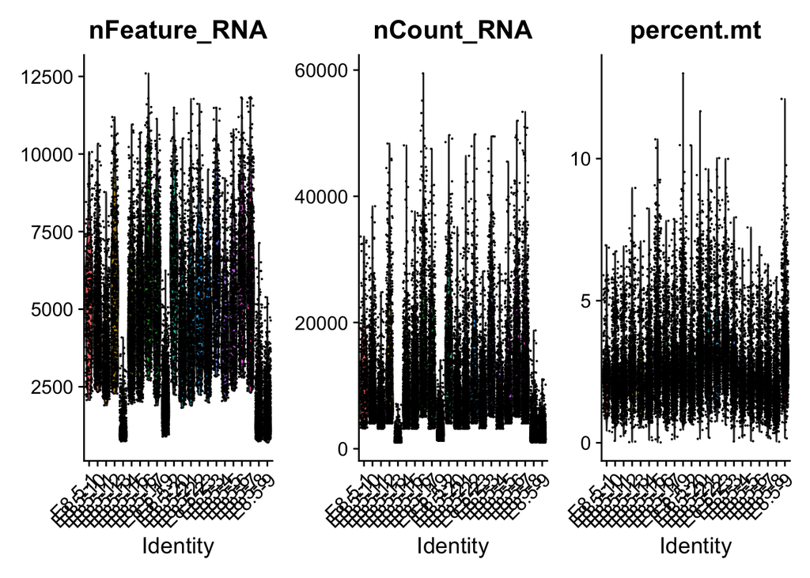

```r
# Quality Control plots voor features, counts en percent.mt
VlnPlot(seurat, features = c("nFeature_RNA", "nCount_RNA", "percent.mt"),
        layer = "counts",
        ncol = 3)
```

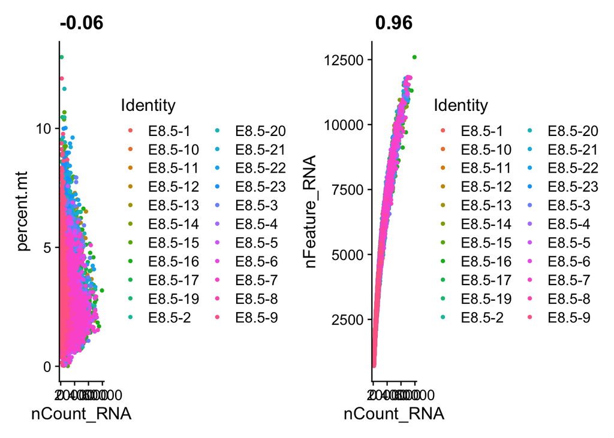

```r
# QC scatterplots
plot1 <- FeatureScatter(seurat, feature1 = "nCount_RNA", feature2 = "percent.mt")
plot2 <- FeatureScatter(seurat, feature1 = "nCount_RNA", feature2 = "nFeature_RNA")
plot1 + plot2
```

```r
# QC filtering, subset van de data
seurat.filtered <- subset(seurat, subset = nFeature_RNA > 200 & nFeature_RNA < 2500 & percent.mt < 6)
```

```r
# Normalisatie, selectie variabele genen, regressie op mitochondriale genexpressie & dataschaling
seurat.filtered <- SCTransform(seurat.filtered, vars.to.regress = "percent.mt", verbose = FALSE)
DefaultAssay(seurat.filtered) <- "SCT"
```

```r
# Toon hoeveel variabele genen er geselecteerd zijn
length(VariableFeatures(seurat.filtered))
```

```
## [1] 3000
```

```r
# 10 meest variabele genen uitzoeken
top10 <- head(VariableFeatures(seurat.filtered), 10)
print(top10)
```

```
##  [1] "Hbb-bh1-exon"  "Ttn-exon"      "Hbb-y-exon"    "Apob-exon"
##  [5] "Slc8a1-intron" "Hba-x-exon"    "Cubn-exon"     "Myh6-exon"
##  [9] "Actc1-exon"    "Ryr2-intron"
```

```
## When using repel, set xnudge and ynudge to 0 for optimal results
```

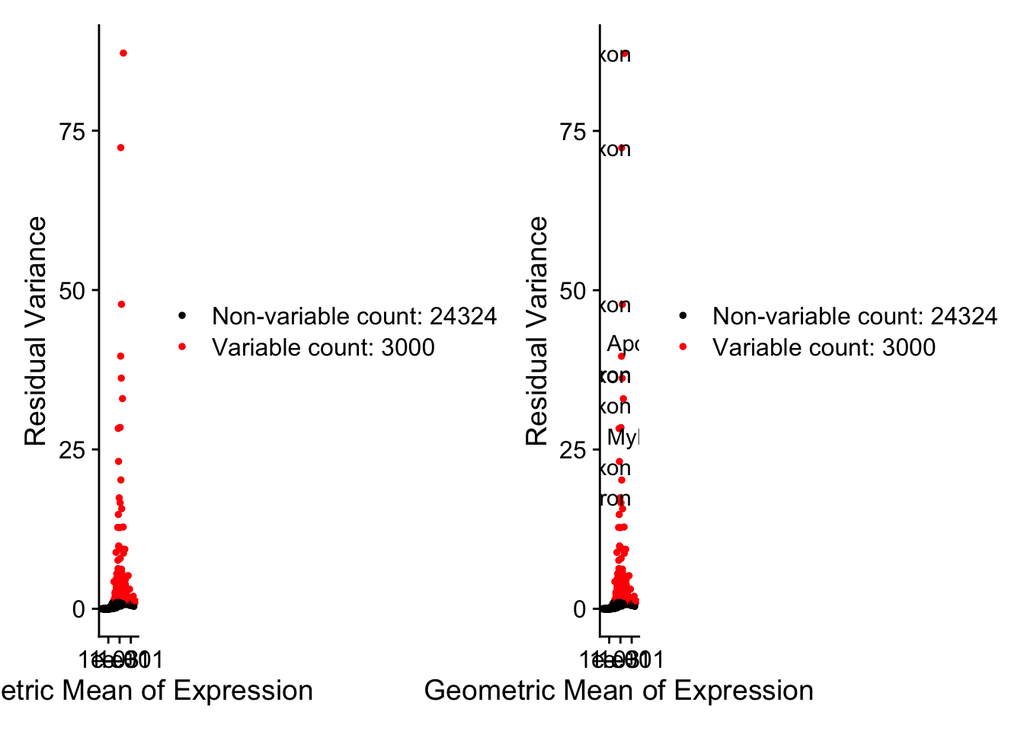

```r
# Controleer of variabele genen beschikbaar zijn
top10 <- head(VariableFeatures(seurat.filtered), 10)

# Plot variabele genen en label de top 10
Plot1 <- VariableFeaturePlot(seurat.filtered)
Plot1 + LabelPoints(plot = Plot1, points = top10, repel = TRUE)
```

```r
seurat.filtered <- RunPCA(seurat.filtered, features = VariableFeatures(seurat.filtered))
```

```
## PC_ 1
## Positive:  H19-exon, Slc2a3-exon, Igf2-Gm49394-exon, Peg10-exon, Apob-exon, Cubn-exon, Apoe-exon, Ahnak-exon, Apoa1-exon, Peg3-exon
##     Afp-exon, Cubn-intron, Rbp4-exon, Igf2r-exon, Tmem108-intron, Slc16a1-exon, Ryr2-intron, Lrp2-exon, Ttr-exon, Fn1-Olfr1270-Ppbp-exon
##     Podxl-exon, Amn-exon, Arhgap6-intron, Rian-exon, Mest-exon, Meg3-Gm27000-exon, Lgmn-exon, Acta2-exon, Lpp-intron, Pakap-intron
## Negative:  Hbb-bh1-exon, Hba-x-exon, Hba-a1-Hba-a2-exon, Gm16867-intron, Hbb-y-exon, Slc25a21-intron, Reln-intron, Slc25a37-Cthrc1-Serpinb12-intron, Slc25a37-Cthrc1-Serpinb12-exon, Slc4a1-exon
##     Ank1-intron, Sptb-intron, Sptb-exon, Ank1-exon, Snca-intron, Car2-exon, Abcb10-exon, Cpox-exon, H2ac7-Hist1h2ap-H2ac12-H2ac4-H2ac13-Hist1h2ao-H2ac11-Hist1h2an-etc-exon, Zdhhc14-intron
##     Bmp2k-intron, Hipk2-intron, Cacna2d3-intron, Prkca-intron, Ikzf1-intron, Hmbs-Itln1-exon, Alas2-exon, Spta1-exon, Csf2rb-exon, Atp8a1-Nipsnap2-Tm2d1-Foxg1-Gm43517-Erich6b-intron
## PC_ 2
## Positive:  Ryr2-intron, Slc8a1-intron, Ttn-exon, Cacna1c-intron, Erbb4-intron, Ttn-intron, Pakap-intron, Actc1-exon, Cacna1d-intron, Myh6-exon
##     Acta2-exon, Slit3-intron, Arhgap6-intron, Ryr2-exon, Cacnb2-intron, Mpped2-intron, Slc8a1-exon, Myh7-exon, Ccdc141-intron, Sdk1-intron
##     Prkg1-intron, Rbm20-intron, Tmem108-intron, 5430431A17Rik-intron, Zfpm2-intron, Myl7-exon, Pcdh7-intron, Mest-exon, Mybpc3-exon, Tbx20-exon
## Negative:  Apob-exon, Cubn-exon, Slc2a3-exon, Apoe-exon, Apoa1-exon, Afp-exon, Rbp4-exon, Cubn-intron, Slc16a1-exon, Ttr-exon
##     Amn-exon, Lgmn-exon, Trf-exon, Slc13a4-exon, Sfmbt2-intron, Lrp2-exon, Emb-Rnf7-Olfr99-exon, Ctsl-exon, Nrk-exon, Apoa4-exon
##     Mttp-exon, Clic6-exon, Ctsb-exon, Ctsh-exon, Dab2-exon, Tmprss2-exon, Myo6-exon, Gldc-exon, Gramd1b-intron, Afp-intron
## PC_ 3
## Positive:  Gpc6-intron, Cadm1-intron, Mllt3-intron, Maml3-intron, Ntn1-intron, Gpc3-intron, Efna5-intron, Tenm4-intron, Tmem132c-intron, Prtg-Serpina16-exon
##     Rnf220-intron, Smoc1-intron, Lef1-intron, Nr6a1-intron, Ror2-intron, Robo2-intron, Fgf14-intron, Prtg-Serpina16-intron, Greb1l-intron, Gli3-intron
##     Zfp423-intron, Meis2-intron, Msi2-intron, Lrig1-intron, Dcc-intron, Pknox2-intron, Fat3-intron, Ncam1-intron, Ptprk-intron, Ptprg-intron
## Negative:  Hbb-bh1-exon, Hba-x-exon, Hba-a1-Hba-a2-exon, Gm16867-intron, Hbb-y-exon, Slc25a21-intron, Ryr2-intron, Ttn-exon, Reln-intron, Slc8a1-intron
##     Ahnak-exon, Ttn-intron, Slc25a37-Cthrc1-Serpinb12-intron, Slc4a1-exon, Ank1-intron, Actc1-exon, Sptb-intron, Slc25a37-Cthrc1-Serpinb12-exon, Sptb-exon, Pakap-intron
##     H19-exon, Acta2-exon, Arhgap6-intron, Myh6-exon, Ank1-exon, Abcb10-exon, Erbb4-intron, Ryr2-exon, Cacna1d-intron, Prkca-intron
## PC_ 4
## Positive:  Ttn-exon, Slc8a1-intron, Ryr2-intron, Erbb4-intron, Ttn-intron, Cacna1c-intron, Actc1-exon, Myh6-exon, Cacna1d-intron, Pakap-intron
##     Myh7-exon, Slc8a1-exon, Cacnb2-intron, Ryr2-exon, Fhod3-intron, 5430431A17Rik-intron, Mybpc3-exon, Myl7-exon, Myh6-intron, Mpped2-intron
##     Ccdc141-intron, Myo18b-intron, Myl4-exon, Ldb3-intron, Ctnna3-intron, Rbm20-intron, Tnnt2-exon, Tnni1-exon, Ank3-intron, Unc45b-exon
## Negative:  Ptprm-Clec3a-intron, Fli1-intron, Kdr-exon, Mest-exon, Hspg2-2210010C04Rik-exon, Ahnak-exon, Adam12-intron, Stab1-exon, Plxnd1-exon, Vim-exon
##     Flt1-intron, Cdh5-exon, Fn1-Olfr1270-Ppbp-exon, Dysf-intron, Shank3-intron, Tek-intron, Galnt18-intron, Prkch-intron, Gas7-intron, Vav3-intron
##     Nid1-Gm28372-1700020A23Rik-exon, Kdr-intron, Gm20532-intron, Flt1-exon, Igf2-Gm49394-exon, Ldb2-intron, Nfib-intron, Tie1-exon, Csgalnact1-intron, Elmo1-intron
## PC_ 5
## Positive:  Ahnak-exon, Tmem108-intron, Bnc2-intron, Col1a1-exon, Col1a2-exon, Slc2a1-exon, Dlk1-exon, Pmp22-exon, Col3a1-exon, Igf2-Gm49394-exon
##     Prdm6-intron, Krt8-exon, Slit3-intron, Svep1-exon, Postn-exon, Peg3-exon, Unc5c-intron, H19-exon, Cobll1-intron, Peg10-exon
##     Col5a2-exon, Smoc2-intron, Trabd2b-intron, Rian-exon, Podxl-exon, Hand1-exon, Adamts9-exon, Sdk1-intron, Lypd6-intron, Svep1-intron
## Negative:  Ptprm-Clec3a-intron, Fli1-intron, Mast4-intron, Kdr-exon, Stab1-exon, Dysf-intron, Cdh5-exon, Shank3-intron, Plxnd1-exon, Flt1-intron
##     Galnt18-intron, Vav3-intron, Prkch-intron, Ldb2-intron, Gas7-intron, Elmo1-intron, Limch1-intron, Gm20532-intron, Palld-intron, Tspan18-intron
##     Csgalnact1-intron, Tie1-exon, Erbb4-intron, Selenop-exon, Kdr-intron, Rapgef5-intron, Ttn-exon, Srgap1-intron, Cd93-exon, Stab2-intron
```

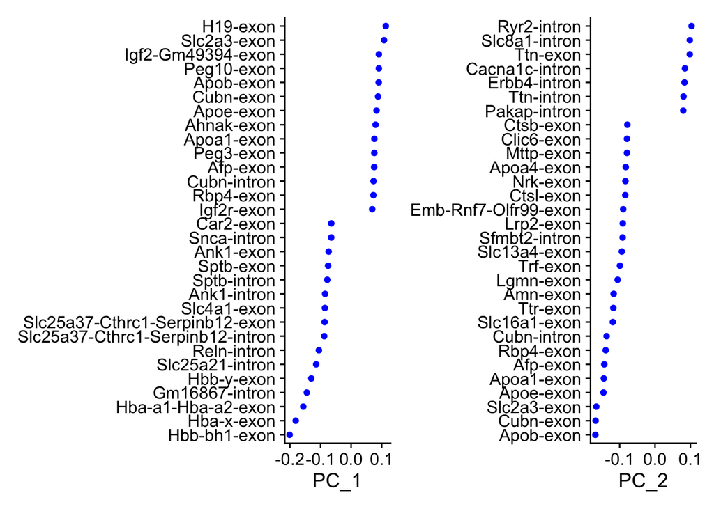

```r
VizDimLoadings(seurat.filtered, dims = 1:2, reduction = "pca")
```

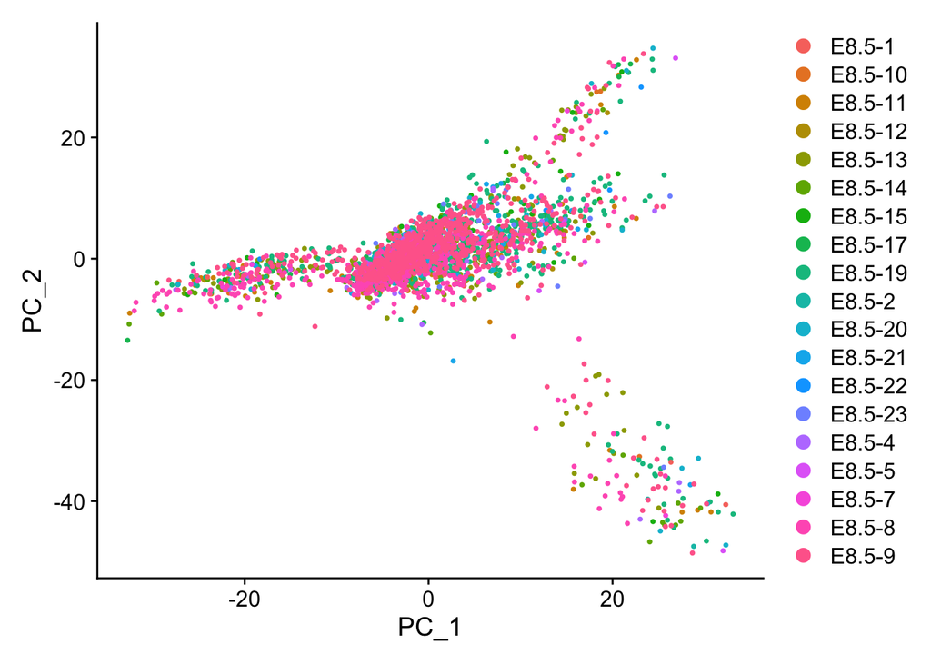

```r
# Visualisatie van cellen in PC-ruimte
DimPlot(seurat.filtered, reduction = "pca")
```

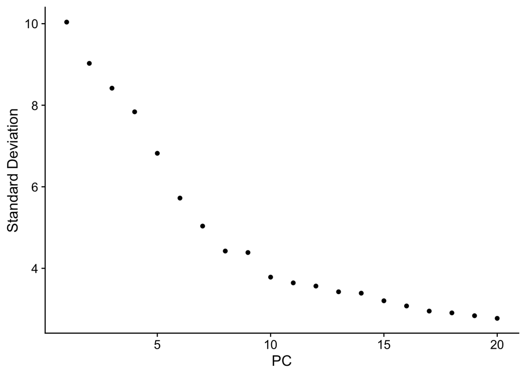

```r
# PCA analyse plotten
ElbowPlot(seurat.filtered)
```

```r
# vind buren, cluster cellen, bereken UMAP en plot het resultaat
seurat.filtered <- FindNeighbors(seurat.filtered, dims = 1:8)
seurat.filtered <- FindClusters(seurat.filtered, resolution = 0.5)
```

```
## Modularity Optimizer version 1.3.0 by Ludo Waltman and Nees Jan van Eck
##
## Number of nodes: 2994
## Number of edges: 89010
##
## Running Louvain algorithm...
## Maximum modularity in 10 random starts: 0.9027
## Number of communities: 10
## Elapsed time: 0 seconds
```

```r
seurat.filtered <- RunUMAP(seurat.filtered, dims = 1:8)
```

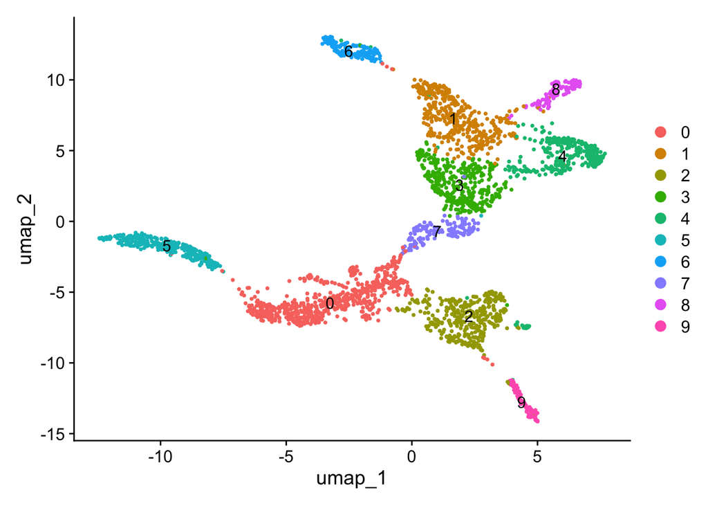

```r
umap_plot <- DimPlot(seurat.filtered, reduction = "umap", label = TRUE)
print(umap_plot)
```

```r
# Bekijk top 3 markergenen per cluster
markers_all <- FindAllMarkers(seurat.filtered, only.pos = TRUE, min.pct = 0.25, logfc.threshold = 0.25)
top3_markers_per_cluster <- markers_all %>%
  group_by(cluster) %>%
  slice_max(order_by = avg_log2FC, n = 3)

print(top3_markers_per_cluster, n = Inf)
```

```
## # A tibble: 30 × 7
## # Groups:   cluster [10]
##        p_val avg_log2FC pct.1 pct.2 p_val_adj cluster gene
##        <dbl>      <dbl> <dbl> <dbl>     <dbl> <fct>   <chr>
##  1 1.03e-135       4.42 0.337 0.023 2.81e-131 0       Nrcam-intron
##  2 1.21e-151       4.38 0.352 0.018 3.29e-147 0       Rfx4-intron
##  3 6.51e-129       3.97 0.346 0.03  1.78e-124 0       Ptprn2-intron
##  4 9.34e-138       6.45 0.273 0.006 2.55e-133 1       Ebf2-intron
##  5 3.63e-147       4.22 0.39  0.027 9.93e-143 1       Col26a1-intron
##  6 3.36e-156       3.95 0.462 0.043 9.18e-152 1       Foxp2-intron
##  7 1.26e-121       4.93 0.269 0.01  3.45e-117 2       Esrp1-intron
##  8 4.89e-109       4.86 0.253 0.011 1.34e-104 2       Grhl2-intron
##  9 5.75e- 97       4.13 0.253 0.015 1.57e- 92 2       Epcam-exon
## 10 2.25e-110       4.80 0.286 0.017 6.14e-106 3       Pcdh19-intron
## 11 9.04e-112       4.40 0.336 0.028 2.47e-107 3       Dll1-exon
```

[output cut: 19 more lines]

```r
# Vergelijk clusters 2 en 3: selecteer top 15 genen per cluster
top_genen <- markers_all %>%
  filter(cluster %in% c(2, 3)) %>%
  group_by(cluster) %>%
  top_n(n = 15, wt = avg_log2FC) %>%
  pull(gene) %>%
  unique()
```

```r
# Top 15 genen per cluster apart
top_2 <- markers_all %>% filter(cluster == 2) %>% top_n(15, avg_log2FC) %>% pull(gene)
top_3 <- markers_all %>% filter(cluster == 3) %>% top_n(15, avg_log2FC) %>% pull(gene)

# Overlap bekijken tussen cluster 2 en 3
overlap <- intersect(top_2, top_3)
print(overlap)
```

```
## character(0)
```

```r
# Maak subset van alleen cluster 2 en 3
seurat_2_3 <- subset(seurat.filtered, idents = c(2,3))

# Combineer de top genen van beide clusters
top_genes <- c(top_2, top_3) %>% unique()
```

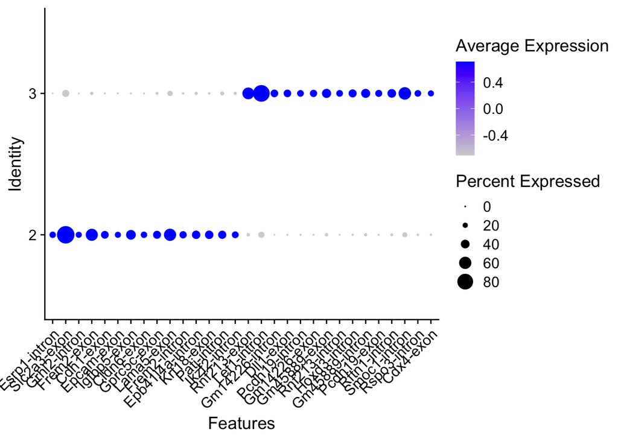

```r
# Maak dotplot voor clusters 2 en 3 met geselecteerde genen
DotPlot(seurat_2_3, features = top_genes) + RotatedAxis()
```

Normaliseren: SCTransform is vooral beter als je data complexer is, met variabele sequencing depth, veel lage expressiewaarden en technische variatie — precies het geval bij VASA-seq. Daarom zie je in moderne pipelines dat SCTransform de voorkeur krijgt.

HVG = 3000: In embryonale datasets is de celdiversiteit doorgaans hoger vanwege de aanwezigheid van diverse celtypes en ontwikkelingsstadia. Dit zorgt voor complexere en subtielere veranderingen in genexpressiepatronen. Door meer variabele genen te selecteren (3000 in plaats van de gebruikelijke 2000) kunnen we deze biologische diversiteit van embryonale ontwikkeling beter vastleggen. Bovendien helpt een grotere genenset om zwakkere signalen op te vangen en verbetert het de detectie van fijne celtypen en subpopulaties.

Na het toepassen van SCTransform() is automatisch een selectie gemaakt van de meest variabele genen binnen de dataset. Dit zijn genen waarvan de expressie sterk verschilt tussen cellen, en ze zijn belangrijk omdat ze vaak bijdragen aan het onderscheiden van celtypes in latere analyses (zoals clustering of trajectanalyse). Om te controleren of deze selectie biologisch logisch is — en niet alleen technische ruis bevat — heb ik de top 10 meest variabele genen bekeken. Deze controle geeft inzicht in welke genen de meeste bijdrage leveren aan de variatie tussen cellen in de dataset. De topgenen bevatten onder andere: - Hemoglobinegenen (Hbb-bh1, Hbb-y, Hba-x): typisch actief in vroege rode bloedcellen in het embryo - Spier- en hartgerelateerde genen (Ttn, Myh6, Actc1, Ryr2): betrokken bij hartontwikkeling, wat past bij cellen in deze embryonale fase - Genen betrokken bij transport en metabolisme (zoals Apob, Cubn, Slc8a1): kunnen wijzen op actieve cellen met functies in vet- of iontransport

extra regressie stap. genen: Tijdens de normalisatie met SCTransform() heb ik het percentage mitochonderiale genexpressie (percent.mt) meegenomen als regressiefactor. dit betekend niet dat mitochondriale genen zijn verwijderd, maar dat hun in vloed op de expressieniveaus van andere genen is gecorrigeerd.zo wordt voorkomen dat variatie door celstress of technische redenen de clustering en downsstream analyses beinvloed.

Om de biologische betekenis van de belangrijkste bronnen van variatie in de dataset te begrijpen, is Principal Component Analysis (PCA) uitgevoerd op de variabele genen.

Met de functie `VizDimLoadings()` zijn de genen geïdentificeerd die het sterkst bijdragen aan PC1 en PC2.

### Interpretatie van PC1

De genen die positief bijdragen aan PC1 omvatten bekende imprintingsgenen en genen betrokken bij groei en ontwikkeling, zoals *H19*, *Igf2*, *Peg10* en *Apoe*. Dit wijst erop dat PC1 mogelijk een biologisch verschil representeert gerelateerd aan imprinting en embryonale ontwikkeling.

De genen die negatief bijdragen aan PC1 zijn voornamelijk gerelateerd aan rode bloedcel functie en ontwikkeling, waaronder verschillende hemoglobine-genen (*Hbb-y*, *Hba-a1*) en cytoskelet-gerelateerde genen (*Ank1*, *Sptb*). Dit suggereert dat PC1 de variatie onderscheidt tussen cellen met een bloedcel-achtige expressie en cellen met een imprintings- en groei-gerelateerde expressie.